# German Electricity Data :electric_plug:

## First steps:

- load the data (with appropriate column types)
- split the data into train/val/test sets
- plot the time series (at different temporal resolution)
- calculate the mean production per month
- is there a seasonal pattern (what kinds of seasonalities)
- make a prediction for the validation set
- evaluate the quality of the prediction

```python
import numpy as np
import pandas as pd
import matplotlib.pyplot as plt
import seaborn as sns
```

```python
np.random.seed(42)
" → ".join(np.random.permutation("Simon Mike Max Chris Felix Joel Robin".split()))
```

```
'Simon → Mike → Joel → Max → Felix → Chris → Robin'
```

```python
np.random.seed(42)
" → ".join(np.random.permutation("Julia1 Julia2 Python".split()))
```

```
'Julia1 → Julia2 → Python'
```

## 1. Data loading

- load the hourly data from the file `Realisierte_Erzeugung_201501010000_202305301300_Stunde.csv` as a table into python :heavy_check_mark:
- make sure, that data is interpreted and typed correctly :heavy_check_mark:
- clean header names :heavy_check_mark:
- create column `Time` containing the combined info from `Datum` and `Anfang`

```python
df = pd.read_csv(
    "../data_dojo_22/Realisierte_Erzeugung_201501010000_202305301300_Stunde.csv",
    delimiter=';',
    decimal=',',
    thousands='.',
    parse_dates=['Datum', 'Anfang', 'Ende'],
    date_format={"Datum": "%d.%m.%Y", "Anfang": "%H:%M", "Ende": "%H:%M"},
    na_values="-"
)
```

```python
df = df.rename(lambda x: x.split(" [")[0].replace(" ","_"), axis="columns")
```

```python
df
```

|  | Datum | Anfang | Ende | Biomasse | Wasserkraft | Wind_Offshore | Wind_Onshore | Photovoltaik | Sonstige_Erneuerbare | Kernenergie | Braunkohle | Steinkohle | Erdgas | Pumpspeicher | Sonstige_Konventionelle |
| --- | --- | --- | --- | --- | --- | --- | --- | --- | --- | --- | --- | --- | --- | --- | --- |
| 0 | 2015-01-01 | 1900-01-01 00:00:00 | 1900-01-01 01:00:00 | 4024.25 | 1158.25 | 516.50 | 8128.00 | 0.00 | 133.00 | 10710.50 | 15687.25 | 3219.75 | 1226.25 | 1525.75 | 4909.25 |
| 1 | 2015-01-01 | 1900-01-01 01:00:00 | 1900-01-01 02:00:00 | 3982.75 | 1188.00 | 516.25 | 8297.50 | 0.00 | 122.50 | 11086.25 | 15321.75 | 2351.25 | 870.75 | 1079.25 | 4932.75 |
| 2 | 2015-01-01 | 1900-01-01 02:00:00 | 1900-01-01 03:00:00 | 4019.50 | 1139.25 | 514.00 | 8540.00 | 0.00 | 93.00 | 11026.25 | 14817.50 | 2227.00 | 809.50 | 787.00 | 5041.75 |
| 3 | 2015-01-01 | 1900-01-01 03:00:00 | 1900-01-01 04:00:00 | 4040.75 | 1122.50 | 517.75 | 8552.00 | 0.00 | 86.50 | 11027.75 | 14075.00 | 2339.75 | 821.00 | 287.75 | 5084.00 |
| 4 | 2015-01-01 | 1900-01-01 04:00:00 | 1900-01-01 05:00:00 | 4037.75 | 1112.00 | 519.75 | 8643.50 | 0.00 | 86.50 | 10962.25 | 14115.00 | 2461.50 | 831.25 | 346.75 | 5070.75 |
| ... | ... | ... | ... | ... | ... | ... | ... | ... | ... | ... | ... | ... | ... | ... | ... |
| 73711 | 2023-05-30 | 1900-01-01 08:00:00 | 1900-01-01 09:00:00 | 4503.50 | 2152.50 | 1643.25 | 3647.75 | 15893.25 | 138.00 | 0.00 | 5181.75 | 1196.25 | 6946.50 | 5079.50 | 1132.00 |
| 73712 | 2023-05-30 | 1900-01-01 09:00:00 | 1900-01-01 10:00:00 | 4544.50 | 2156.25 | 1285.00 | 2900.50 | 23612.50 | 135.00 | 0.00 | 4707.50 | 1114.75 | 6384.50 | 2122.75 | 1115.00 |
| 73713 | 2023-05-30 | 1900-01-01 10:00:00 | 1900-01-01 11:00:00 | 4568.25 | 2085.25 | 1241.25 | 2729.50 | 30341.75 | 121.25 | 0.00 | 3978.50 | 1095.50 | 4802.50 | 1279.00 | 1096.25 |
| 73714 | 2023-05-30 | 1900-01-01 11:00:00 | 1900-01-01 12:00:00 | 4618.75 | 2068.25 | 1053.25 | 3115.00 | 35196.25 | 119.00 | 0.00 | 3759.75 | 1151.50 | 3762.25 | 774.00 | 1096.50 |
| 73715 | 2023-05-30 | 1900-01-01 12:00:00 | 1900-01-01 13:00:00 | 4612.25 | 1967.25 | 781.25 | 3496.25 | 37030.00 | 119.00 | 0.00 | 3765.00 | 1296.75 | 3240.00 | 196.75 | 1099.75 |

73716 rows × 15 columns

### Todo 2<sup>nd</sup> session

- Create `Time` column
- Split into training/validation/test set
- Plot the training set with hourly resolution
- Aggregate by day/month
- Plot aggregated data

**Bonus task**

- did you observe something peculiar with dates and times?
- look at the hourly data of 2017-10-29 for an example
- what happened there?
- are there more days with a similar "problem"?
- is this a problem?
- how can we solve this?

Todos 4th Session

Create a manual prediction model (with hard-coded rules) for "Photovoltaik" How accurately does your manually created model predict the values in the validation set?

Bonus:

Employ a more sophisticated prediction model from an existing package for time series analysis How does the prediction of that model compare to your manual model?

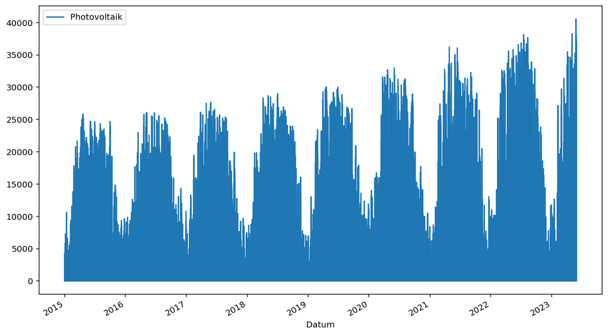

```python
df.plot(x="Datum", y="Photovoltaik")
```

```python
df_train = df[df.Datum < pd.to_datetime('2021-01-01')]
df_val = df[(pd.to_datetime('2021-12-31') >= df.Datum) & (df.Datum >= pd.to_datetime('2021-01-01'))]
df_test = df[(pd.to_datetime('2021-12-31') < df.Datum)]
```

pls give code for manual prediction model

```python
# Create manual prediction model

def manual_prediction_model(input_data):
    pass
```

```python
df.Datum.apply(lambda x: str(x))
```

```
0        2015-01-01 00:00:00
1        2015-01-01 00:00:00
2        2015-01-01 00:00:00
3        2015-01-01 00:00:00
4        2015-01-01 00:00:00
                ...
73711    2023-05-30 00:00:00
73712    2023-05-30 00:00:00
73713    2023-05-30 00:00:00
73714    2023-05-30 00:00:00
73715    2023-05-30 00:00:00
Name: Datum, Length: 73716, dtype: object
```

```python
p = np.polyfit(x= df_train.index, y = df_train["Photovoltaik"], deg = 5)
print(p)
```

```
[-2.90188903e-19  2.93407736e-14 -9.22854477e-10  8.98555223e-06
  2.23514325e-02  3.70831543e+03]
```

```python
func = lambda x: p[5] + p[4] * x + p[3] * x**2 + p[2] * x**3 + p[1] * x**4 + p[0] * x**5
```

```python
df_val.tail()
```

|  | Datum | Anfang | Ende | Biomasse | Wasserkraft | Wind_Offshore | Wind_Onshore | Photovoltaik | Sonstige_Erneuerbare | Kernenergie | Braunkohle | Steinkohle | Erdgas | Pumpspeicher | Sonstige_Konventionelle |
| --- | --- | --- | --- | --- | --- | --- | --- | --- | --- | --- | --- | --- | --- | --- | --- |
| 61363 | 2021-12-31 | 1900-01-01 19:00:00 | 1900-01-01 20:00:00 | 4564.50 | 1555.75 | 5697.25 | 33039.25 | 0.0 | 154.00 | 5863.00 | 3765.25 | 2279.50 | 2697.75 | 1180.00 | 1435.75 |
| 61364 | 2021-12-31 | 1900-01-01 20:00:00 | 1900-01-01 21:00:00 | 4463.00 | 1530.50 | 6169.25 | 30699.75 | 0.0 | 154.00 | 5574.75 | 3758.00 | 2203.75 | 2675.75 | 787.75 | 1442.25 |
| 61365 | 2021-12-31 | 1900-01-01 21:00:00 | 1900-01-01 22:00:00 | 4403.25 | 1586.75 | 6132.75 | 27932.75 | 0.0 | 155.50 | 4918.75 | 3767.75 | 2185.75 | 2662.00 | 593.50 | 1445.25 |
| 61366 | 2021-12-31 | 1900-01-01 22:00:00 | 1900-01-01 23:00:00 | 4382.00 | 1505.25 | 6041.50 | 27079.25 | 0.0 | 157.75 | 4070.25 | 3777.75 | 2145.25 | 2658.50 | 1027.50 | 1439.50 |
| 61367 | 2021-12-31 | 1900-01-01 23:00:00 | 1900-01-01 00:00:00 | 4363.75 | 1462.50 | 6313.25 | 25797.75 | 0.0 | 158.25 | 3224.50 | 3625.00 | 2115.75 | 2660.50 | 809.75 | 1455.75 |

```python
x = list(range(52608, 61368))
pred = [func(i) for i in x]
```

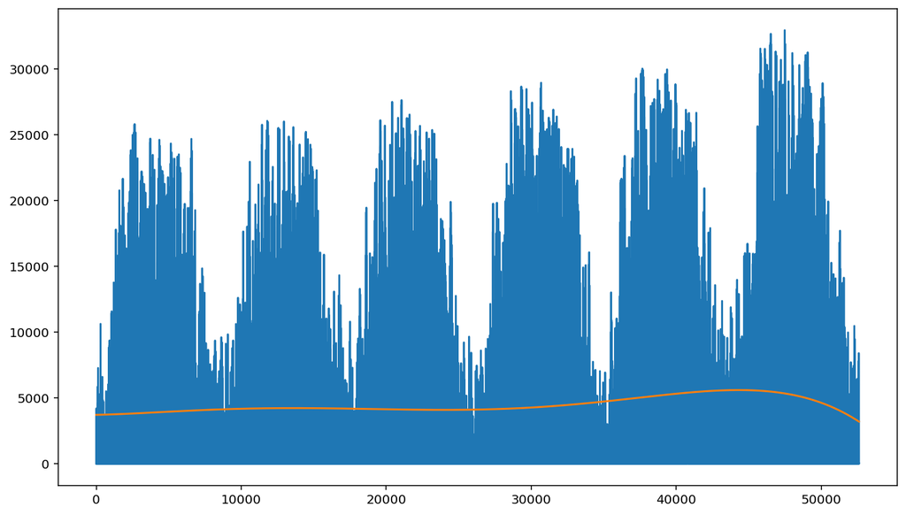

```python
plt.plot(df_train.index, df_train.Photovoltaik)
plt.plot(df_train.index, [func(i) for i in df_train.index])
```

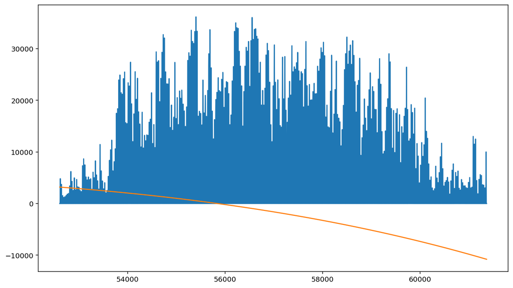

```python
plt.plot(df_val.index, df_val.Photovoltaik)
plt.plot(df_val.index, [func(i) for i in df_val.index])
```

Calculate MAE of this prediction in the validation set

```python
pred = np.array([func(i) for i in df_val.index])
np.mean(np.abs(df_val.Photovoltaik.values - pred))
```

```
8499.14687240829
```